# Tibbles and Data Transformation

01 November 2018

## Agenda

- Tibbles and data frames
- Tidy data
- The tidyverse
- Data transformation

## Tibbles and data frames

## First look

```r
library(dplyr)
starwars
```

## First look

```r
library(dplyr)
starwars
```

```
## # A tibble: 87 x 13
##    name  height  mass hair_color skin_color eye_color birth_year gender
##    <chr>  <int> <dbl> <chr>      <chr>      <chr>          <dbl> <chr>
##  1 Luke…    172    77 blond      fair       blue            19   male
##  2 C-3PO    167    75 <NA>       gold       yellow         112   <NA>
##  3 R2-D2     96    32 <NA>       white, bl… red             33   <NA>
##  4 Dart…    202   136 none       white      yellow          41.9 male
##  5 Leia…    150    49 brown      light      brown           19   female
##  6 Owen…    178   120 brown, gr… light      blue            52   male
##  7 Beru…    165    75 brown      light      blue            47   female
##  8 R5-D4     97    32 <NA>       white, red red             NA   <NA>
##  9 Bigg…    183    84 black      light      brown           24   male
## 10 Obi-…    182    77 auburn, w… fair       blue-gray       57   male
## # ... with 77 more rows, and 5 more variables: homeworld <chr>,
## #   species <chr>, films <list>, vehicles <list>, starships <list>
```

## First look

```r
library(dplyr)
as.data.frame(starwars)
```

```
##                     name height   mass    hair_color          skin_color
## 1         Luke Skywalker    172   77.0         blond                fair
## 2                  C-3PO    167   75.0          <NA>                gold
## 3                  R2-D2     96   32.0          <NA>         white, blue
## 4            Darth Vader    202  136.0          none               white
## 5            Leia Organa    150   49.0         brown               light
## 6              Owen Lars    178  120.0   brown, grey               light
## 7     Beru Whitesun lars    165   75.0         brown               light
## 8                  R5-D4     97   32.0          <NA>          white, red
## 9      Biggs Darklighter    183   84.0         black               light
## 10        Obi-Wan Kenobi    182   77.0 auburn, white                fair
## 11      Anakin Skywalker    188   84.0         blond                fair
## 12        Wilhuff Tarkin    180     NA  auburn, grey                fair
## 13             Chewbacca    228  112.0         brown             unknown
## 14              Han Solo    180   80.0         brown                fair
## 15                Greedo    173   74.0          <NA>               green
## 16 Jabba Desilijic Tiure    175 1358.0          <NA>    green-tan, brown
## 17        Wedge Antilles    170   77.0         brown                fair
## 18      Jek Tono Porkins    180  110.0         brown                fair
## 19                  Yoda     66   17.0         white               green
## 20             Palpatine    170   75.0          grey                pale
## 21             Boba Fett    183   78.2         black                fair
## 22                 IG-88    200  140.0          none               metal
## 23                 Bossk    190  113.0          none               green
## 24      Lando Calrissian    177   79.0         black                dark
## 25                 Lobot    175   79.0          none               light
## 26                Ackbar    180   83.0          none        brown mottle
## 27            Mon Mothma    150     NA        auburn                fair
## 28          Arvel Crynyd     NA     NA         brown                fair
## 29 Wicket Systri Warrick     88   20.0         brown               brown
## 30             Nien Nunb    160   68.0          none                grey
## 31          Qui-Gon Jinn    193   89.0         brown                fair
## 32           Nute Gunray    191   90.0          none       mottled green
## 33         Finis Valorum    170     NA         blond                fair
## 34         Jar Jar Binks    196   66.0          none              orange
## 35          Roos Tarpals    224   82.0          none                grey
## 36            Rugor Nass    206     NA          none               green
## 37              Ric Olié    183     NA         brown                fair
## 38                 Watto    137     NA         black          blue, grey
## 39               Sebulba    112   40.0          none           grey, red
```

[output cut: 385 more lines]

[output not shown]

## Tibbles

```r
vignette("tibble")
```

Tibbles are a modern take on data frames. They keep the features that have stood the test of time, and drop the features that used to be convenient but are now frustrating.

- You should always use tibbles

## Data frames

Data frames consist of:

- rows representing observations
- columns representing variables
- every column has one type

## Column types

- Numbers:
  - `dbl`: real numbers
  - `int`: integers
- `lgl`: boolean (true/false)
- `chr`: Characters
- `fct`: Factors
- many other types

## Factors

- represent categorical variables

```r
colleges <- c("St Edmund", "Exeter", "Queen's", "St John's")
x <- c("St Edmund", "Exeter", "St Edmund", "Queen's",
       "St Edmund", "Queen's", "Exeter", "Exeter")
fct <- factor(x, levels = colleges)
fct
```

```
## [1] St Edmund Exeter    St Edmund Queen's   St Edmund Queen's   Exeter
## [8] Exeter
## Levels: St Edmund Exeter Queen's St John's
```

```r
str(fct)
```

```
##  Factor w/ 4 levels "St Edmund","Exeter",..: 1 2 1 3 1 3 2 2
```

## Structure of factors

```r
attributes(fct)
```

```
## $levels
## [1] "St Edmund" "Exeter"    "Queen's"   "St John's"
##
## $class
## [1] "factor"
```

```r
levels(fct)
```

```
## [1] "St Edmund" "Exeter"    "Queen's"   "St John's"
```

## Exercise 1

1. Create a tibble with three rows (different students) and the two variables `name` (as a character) and `college` (as a character). (If someone does not have a college, type in "NA" (not applicable).)
2. Turn the character column into a factor.
3. Dangers with factors: what is happening in the following two lines of code?

```r
as.integer(c("1", "2"))
```

```
## [1] 1 2
```

```r
as.integer(factor(c("2", "1")))
```

```
## [1] 2 1
```

## Tidy data

## Tidy data

http://www.jstatsoft.org/v59/i10/paper

[figure not shown]

## Tolstoy in statistics

"Happy families are all alike; every unhappy family is unhappy in its own way." - Leo Tolstoy

"Tidy datasets are alike but every messy dataset is messy in its own way." - Hadley Wickham

- A standardized format for datasets makes their manipulation easier.
1. Each variable forms a column.
2. Each observation forms a row.
3. Each type of observational unit forms a table.

## Messy data: example

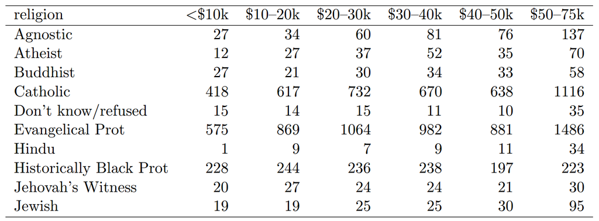

- Problem: Variable headers are values

## Messy data: solution

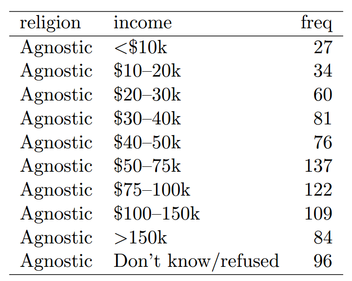

## Remarks on tidy data

- the principles of tidy data might seem trivial but they are not
- functions expect tidy input and give tidy output (exceptions are e. g. visualizations)

## The tidyverse

## The tidyverse

- the tidyverse implements a tidy approach towards data analysis

```r
install.packages("tidyverse")
library(tidyverse)
```

## Coding style

- a variable is an object
- a function is a verb
- the pipe `%>%` connects objects and verbs

```r
diamonds %>%
  filter(cut == "Ideal") %>%
  select(carat, clarity)
```

## Coding style

```
## # A tibble: 21,551 x 2
##    carat clarity
##    <dbl> <ord>
##  1  0.23 SI2
##  2  0.23 VS1
##  3  0.31 SI2
##  4  0.3  SI2
##  5  0.33 SI2
##  6  0.33 SI2
##  7  0.33 SI1
##  8  0.23 VS1
##  9  0.32 SI1
## 10  0.3  SI2
## # ... with 21,541 more rows
```

## The pipe

```r
diamonds %>%
  filter(cut == "Ideal")
```

is actually

```r
filter(diamonds, cut == "Ideal")
```

## The pipe

```r
diamonds %>%
  filter(cut == "Ideal") %>%
  select(carat, clarity)
```

is actually

```r
select(
  filter(diamonds, cut == "Ideal"),
  carat, clarity
)
```

## The pipe makes code more readable

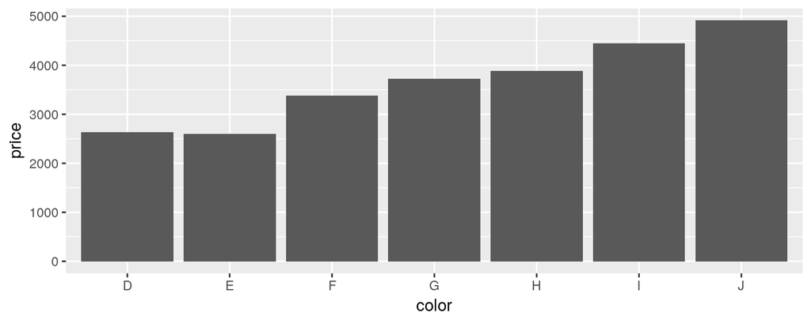

```r
diamonds %>%
  filter(cut == "Ideal") %>%
  group_by(color) %>%
  summarise(price = mean(price)) %>%
  ggplot(aes(x = color, y = price)) +
  geom_bar(stat = "identity")
```

## Exercise 2

Split the following chunks of code up using the pipe:

```r
select(
  diamonds,
  color, cut, clarity
)
```

```r
filter(
  select(
    diamonds,
    color, cut, clarity, depth
  ),
  depth >= 60
)
```

## Data transformation

## Select variables

- `select` selects all given, unquoted variables
- there are special functions to help with selection

```r
diamonds
```

```
## # A tibble: 53,940 x 10
##    carat cut       color clarity depth table price     x     y     z
##    <dbl> <ord>     <ord> <ord>   <dbl> <dbl> <int> <dbl> <dbl> <dbl>
##  1 0.23  Ideal     E     SI2      61.5    55   326  3.95  3.98  2.43
##  2 0.21  Premium   E     SI1      59.8    61   326  3.89  3.84  2.31
##  3 0.23  Good      E     VS1      56.9    65   327  4.05  4.07  2.31
##  4 0.290 Premium   I     VS2      62.4    58   334  4.2   4.23  2.63
##  5 0.31  Good      J     SI2      63.3    58   335  4.34  4.35  2.75
##  6 0.24  Very Good J     VVS2     62.8    57   336  3.94  3.96  2.48
##  7 0.24  Very Good I     VVS1     62.3    57   336  3.95  3.98  2.47
##  8 0.26  Very Good H     SI1      61.9    55   337  4.07  4.11  2.53
##  9 0.22  Fair      E     VS2      65.1    61   337  3.87  3.78  2.49
## 10 0.23  Very Good H     VS1      59.4    61   338  4     4.05  2.39
## # ... with 53,930 more rows
```

## `select`: drop variables

```r
diamonds %>%
  select(-x, -y, -z)
```

```
## # A tibble: 53,940 x 7
##    carat cut       color clarity depth table price
##    <dbl> <ord>     <ord> <ord>   <dbl> <dbl> <int>
##  1 0.23  Ideal     E     SI2      61.5    55   326
##  2 0.21  Premium   E     SI1      59.8    61   326
##  3 0.23  Good      E     VS1      56.9    65   327
##  4 0.290 Premium   I     VS2      62.4    58   334
##  5 0.31  Good      J     SI2      63.3    58   335
##  6 0.24  Very Good J     VVS2     62.8    57   336
##  7 0.24  Very Good I     VVS1     62.3    57   336
##  8 0.26  Very Good H     SI1      61.9    55   337
##  9 0.22  Fair      E     VS2      65.1    61   337
## 10 0.23  Very Good H     VS1      59.4    61   338
## # ... with 53,930 more rows
```

## `select`: `:` picks adjacent variables

```r
diamonds %>%
  select(carat:price)
```

```
## # A tibble: 53,940 x 7
##    carat cut       color clarity depth table price
##    <dbl> <ord>     <ord> <ord>   <dbl> <dbl> <int>
##  1 0.23  Ideal     E     SI2      61.5    55   326
##  2 0.21  Premium   E     SI1      59.8    61   326
##  3 0.23  Good      E     VS1      56.9    65   327
##  4 0.290 Premium   I     VS2      62.4    58   334
##  5 0.31  Good      J     SI2      63.3    58   335
##  6 0.24  Very Good J     VVS2     62.8    57   336
##  7 0.24  Very Good I     VVS1     62.3    57   336
##  8 0.26  Very Good H     SI1      61.9    55   337
##  9 0.22  Fair      E     VS2      65.1    61   337
## 10 0.23  Very Good H     VS1      59.4    61   338
## # ... with 53,930 more rows
```

## `select`: special functions

- see manual

```r
diamonds %>%
  select(carat, ends_with("e"))
```

```
## # A tibble: 53,940 x 3
##    carat table price
##    <dbl> <dbl> <int>
##  1 0.23     55   326
##  2 0.21     61   326
##  3 0.23     65   327
##  4 0.290    58   334
##  5 0.31     58   335
##  6 0.24     57   336
##  7 0.24     57   336
##  8 0.26     55   337
##  9 0.22     61   337
## 10 0.23     61   338
## # ... with 53,930 more rows
```

## Exercises: Preliminary remarks

For our exercises, we will look at the `nycflights13` dataset:

```r
install.packages("nycflights13")
library(nycflights13)
```

The `dplyr` cheatsheet might be helpful: https://www.rstudio.org/links/data_transformation_cheat_sheet

## Exercise 3

Solve the exercises in: https://r4ds.had.co.nz/transform.html#exercises-9

## Filter the data frame

- use logical criteria to filter rows
- you can use the data frame's variables

```r
diamonds %>%
  filter(cut == "Ideal")
```

```r
diamonds %>%
  filter(cut == "Ideal", depth >= 60)
```

## Logical operators

- Compare values:
  - `x == y`: Are x and y equal?
  - `x != y`: Are x and y not equal?
- Modify logical values:
  - `!x`: not x
  - `x | y`: x or y
  - `x & y`: x and y

## Exercise 4

Solve exercises 1 and 2 in: https://r4ds.had.co.nz/transform.html#exercises-7

## Mutate the data frame

- `mutate` adds new variables
- you can use the values of other variables within the variables
- uses *vectorized functions*

```r
diamonds %>%
  mutate(price_per_carat = price / carat)
```

## Vectorized functions

- Vectorized functions return one value for each entry
  - examples: `x + y`, `log(x)`, `==`

## Exercise 5

Solve exercises 2 and 3 in: https://r4ds.had.co.nz/transform.html#exercises-10

## Group the data frame

```r
diamonds %>%
  group_by(cut)
```

```
## # A tibble: 53,940 x 10
## # Groups:   cut [5]
##    carat cut       color clarity depth table price     x     y     z
##    <dbl> <ord>     <ord> <ord>   <dbl> <dbl> <int> <dbl> <dbl> <dbl>
##  1 0.23  Ideal     E     SI2      61.5    55   326  3.95  3.98  2.43
##  2 0.21  Premium   E     SI1      59.8    61   326  3.89  3.84  2.31
##  3 0.23  Good      E     VS1      56.9    65   327  4.05  4.07  2.31
##  4 0.290 Premium   I     VS2      62.4    58   334  4.2   4.23  2.63
##  5 0.31  Good      J     SI2      63.3    58   335  4.34  4.35  2.75
##  6 0.24  Very Good J     VVS2     62.8    57   336  3.94  3.96  2.48
##  7 0.24  Very Good I     VVS1     62.3    57   336  3.95  3.98  2.47
##  8 0.26  Very Good H     SI1      61.9    55   337  4.07  4.11  2.53
##  9 0.22  Fair      E     VS2      65.1    61   337  3.87  3.78  2.49
## 10 0.23  Very Good H     VS1      59.4    61   338  4     4.05  2.39
## # ... with 53,930 more rows
```

## Summarise the groups

```r
diamonds %>%
  group_by(color) %>%
  summarise(mean_price = mean(price))
```

```
## # A tibble: 7 x 2
##   color mean_price
##   <ord>      <dbl>
## 1 D          3170.
## 2 E          3077.
## 3 F          3725.
## 4 G          3999.
## 5 H          4487.
## 6 I          5092.
## 7 J          5324.
```

## Exercise 6

1. Determine the mean price for each cut
2. Determine the number of occurrences for each cut (hint: look at `n()`)
3. Determine the maximal price and the maximal carat for each color
4. Determine the mean price for each combination of cut and color

## Further reading

- R4DS, ch. 5, 9, 10, 12
- "Tidy data" by Hadley Wickham: http://www.jstatsoft.org/v59/i10/paper
- Introduction to the tidyverse: tidyverse.org
- `dplyr` cheatsheet: https://www.rstudio.org/links/data_transformation_cheat_sheet